# HR_Consulting_Project

Ian Blad

2025-03-31

```r
library(GGally)
library(ggplot2)
library(dbplyr)
library(mosaic)
library(ggcorrplot)
library(dplyr)
library(broom)
library(knitr)
library(pander)
```

We are doing a mock consulting project for a tech company that is trying to figure out how to reduce their turnover rate. The company has been around for a little more than a year and has had many very talented programmers and managers, who have left. They have a very high turnover rate and so they have sent out a survey to their employees to try and figure out what is going on. They have also sent us their HR data so we can analyze it and see if we can find any patterns that might help them.

The survey that was sent out is attached to this file along with the code that was used to generate the data. The survey is a Likert scale survey that asks employees about their job satisfaction, career growth perception, intent to stay, autonomy in work, and job embedness. The HR data includes information about the employees’ age, job level, salary, education, location, department, performance rating, and promotion history. The data was generated using a simulation model with well done research on the factors that influence retention in mind.

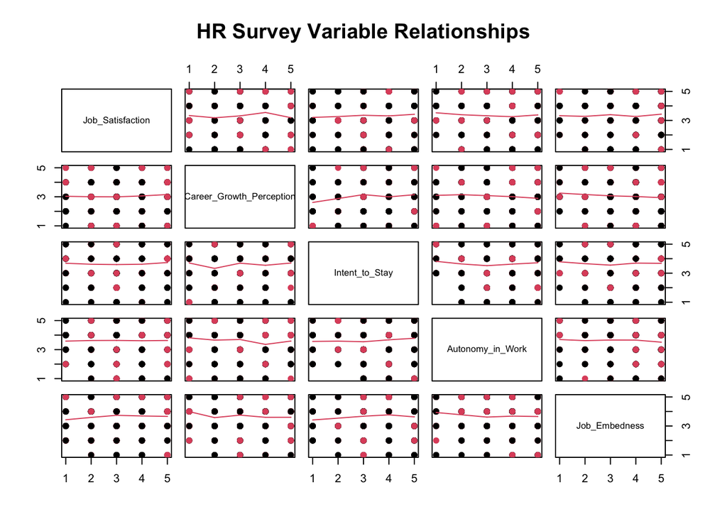

```r
set.seed(123)  # Ensuring reproducibility
n <- 537  # Number of employees

# Step 1: HR-Related Data #
age <- round(rnorm(n, mean = 30, sd = 5))

job_level <- sample(1:7, n, replace = TRUE, prob = c(0.1, 0.15, 0.2, 0.2, 0.15, 0.1, 0.1))
# Varying levels of employment, from entry level to head of corporate offices.

salary <- job_level * sample(5000:10000, n, replace = TRUE) + rnorm(n, mean = 20000, sd = 5000)
# in dollars

education <- sample(0:4, n, replace = TRUE, prob = c(0.05, 0.15, 0.3, 0.3, 0.2))
# 0=Highschool, 1=Associates, 2=Bachelors 3=Masters 4=Doctorate

locations <- sample(c("New York", "San Francisco", "Chicago", "Austin", "Seattle", "Denver", "Miami"), n, replace = TRUE)

departments <- sample(c("Engineering & Dev", "Product & Design", "IT & Security", "Sales & Marketing", "Customer & HR", "Leadership"), n, replace = TRUE)

performance_ratings <- sample(2:10, n, replace = TRUE, prob = c(0.05, 0.05, 0.05, 0.05, 0.1, 0.25, 0.25, 0.1, 0.1))

### Step 2: Modify HR Survey Data to Use Likert Scales ###
# Likert scale values (1 to 5)
job_satisfaction <- sample(1:5, n, replace = TRUE, prob = c(0.05, 0.15, 0.35, 0.3, 0.15))
career_growth_perception <- sample(1:5, n, replace = TRUE, prob = c(0.1, 0.2, 0.4, 0.2, 0.1))
intent_to_stay <- sample(1:5, n, replace = TRUE, prob = c(0.05, 0.1, 0.3, 0.4, 0.15))
autonomy_in_work <- sample(1:5, n, replace = TRUE, prob = c(0.05, 0.1, 0.3, 0.35, 0.2))
job_embedness <- sample(1:5, n, replace = TRUE, prob = c(0.05, 0.1, 0.3, 0.35, 0.2))


# Step 3: Calculate Retention Based on Constructs ###
# Assuming a simple function or formula to calculate retention as you described:
retention_probability <- 0.6 + 0.4 * job_satisfaction + 0.2 * career_growth_perception +
                         0.25 * intent_to_stay + 0.2 * autonomy_in_work + 0.3 * job_embedness

retention_probability <- retention_probability*.1

# Apply promotion effect (23% chance of leaving within 6 months)
promotion_history <- sample(0:3, n, replace = TRUE, prob = c(0.3, 0.3, 0.2, 0.2))  # 0-3 promotions possible
promotion_leave_probability <- ifelse(promotion_history > 0, 0.21, 0)

# Adjust retention based on promotion history (i.e., chance of leaving)
retention_probability <- retention_probability - promotion_leave_probability

# Apply low performer department and location effect (30% lower retention)
low_performers <- performance_ratings >= 2 & performance_ratings <= 4  # Identifying low performers
low_performer_effect <- 0.33  # 30% lower retention

retention_probability[low_performers] <- retention_probability[low_performers] * (1 - low_performer_effect)

# Ensure the retention probability stays within reasonable bounds (0 to 1)
retention_probability <- pmin(pmax(retention_probability, 0), 1)

# Step 4: Determine if employee leaves or stays based on retention probability
# Generate random values to simulate whether each employee stays or leaves
leaves <- runif(n) < retention_probability

# Print summary to check the retention rates
# summary(leaves)



### Step 5: Compile Data Frame ###
HR_data <- data.frame(
  Age = age,
  Job_Level = as.factor(job_level),
  Salary = salary,
  Education = as.factor(education),
  Location = as.factor(locations),
  Department = as.factor(departments),
  Performance_Rating = performance_ratings,
  Promotion_History = as.factor(promotion_history),
  Job_Satisfaction = job_satisfaction,
  Career_Growth_Perception = career_growth_perception,
  Intent_to_Stay = intent_to_stay,
  Autonomy_in_Work = autonomy_in_work,
  Job_Embedness = job_embedness,
  Leaves = as.factor(leaves)  # Outcome variable for retention
)




survey_vars <- HR_data[, c("Job_Satisfaction", "Career_Growth_Perception",
                                "Intent_to_Stay", "Autonomy_in_Work", "Job_Embedness")]

# Select traditional HR variables (excluding Leaves)
traditional_vars <- HR_data[, c("Age", "Job_Level", "Salary", "Education",
                                     "Location", "Department", "Performance_Rating",
                                     "Promotion_History")]

# Plot 1: Survey variables
pairs(survey_vars,
      main = "HR Survey Variable Relationships",
      col = HR_data$Leaves,
      pch = 19, panel=panel.smooth)
```

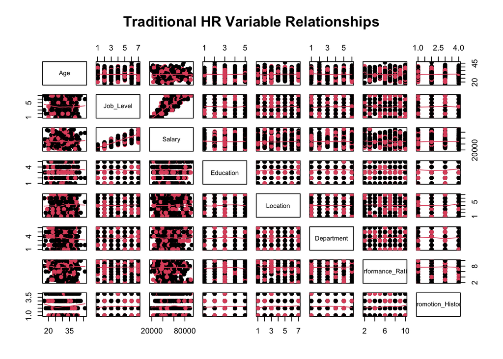

```r
# Plot 2: Traditional HR variables
pairs(traditional_vars,
      main = "Traditional HR Variable Relationships",
      col = HR_data$Leaves,
      pch = 19,panel=panel.smooth)
```